# Multivariate Analysis Lecture 15: Model-Free Clustering

Zhaoxia Yu

Professor, Department of Statistic

2026-05-31

```r
knitr::opts_chunk$set(echo = TRUE)
library(tidyr) #the pipe (%>%) tool is extremely useful
library(MASS)
library(ggplot2)
library(kableExtra)
library("gridExtra")
library(knitr)
library(magick) #install.packages("magick") #dynamic image
```

# Introduction to Cluster Analysis

## Introduction to Cluster Analysis

- Exploratory
- Aims to understand/ learn the unknown substructure of multivariate data
- Seeks rules to group data
  - Large between-group difference
  - Small within-group difference

## Cluster Analysis vs Classification Analysis

- Cluster analysis: “**unsupervised**” learning
  - Data are unlabeled
  - The number of clusters are unknown
- Classification: “**supervised**” learning
  - The labels for training data are known
  - The number of classes are known
  - Want to allocate new observations, whose labels are unknown, to one of the known classes

## Clustering Methods

- Model-free:
  - Hierarchical clustering. Based on similarity measures.
  - Nonhierarchical clustering. For example, K-means.
- Model-based clustering.

# Hierarchical Clustering

- Hierarchical clustering seeks to build a hierarchy of clusters.
- The result of hierarchical clustering is usually presented in a dendrogram.

## Two Major Types of Hierarchical Clustering

- Hierarchical clustering can be divided into two types:
  - Agglomerative clustering
    - Bottom-up approach
    - Start with each object in its own cluster and merge them into larger clusters
  - Divisive clustering
    - Top-down approach
    - Start with all objects in one cluster and divide them into smaller clusters

### Agglomerative Clustering

- Agglomerative clustering is a bottom-up approach to hierarchical clustering.
- The algorithm works as follows:
  1. Start with each object in its own cluster
  2. Merge the closest pair of clusters
  3. Repeat steps 2 until only one cluster remains
- Measure distance
  1. between two objects
  2. between two clusters (also known as linkage)

## Distance Between Data Points

- *Euclidean*: the straight-line distance between two points

We will use Euclidean distance for examples in this lecture.

- *Manhattan*: the sum of the absolute differences between the coordinates of the points
- *Minkowski*: a generalization of both Euclidean and Manhattan distances
- *Mahalanobis*: a measure of the distance between a point and a distribution

## Linkage Between Clusters

- *Single* linkage: distance between the closest pair of objects in the two clusters
- *Complete* linkage: distance between the farthest pair of objects in the two clusters
- *Average* linkage: average distance between all pairs of objects in the two clusters
- *Centroid* linkage: distance between the centroids of the two clusters

# Example

## Data

- Four points 1, 1.5, 3, 5

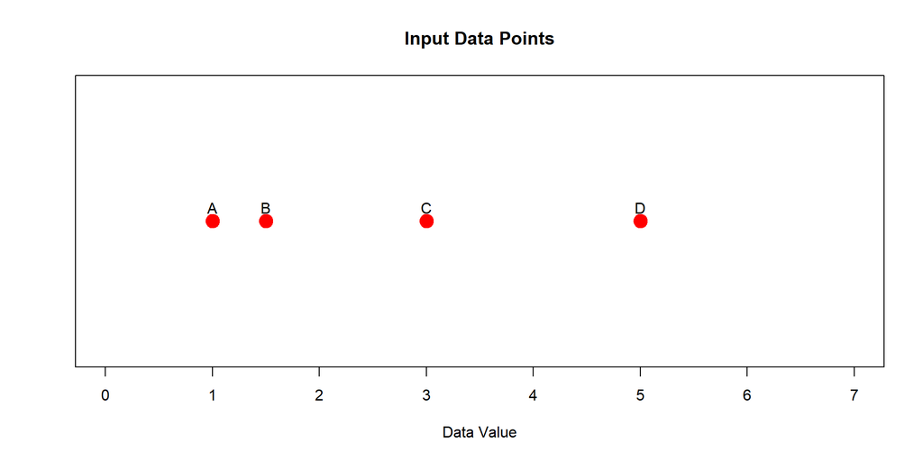

```r
# Sample data
data <- data.frame(
  x = c(1, 1.5, 3, 5),  # X-coordinates
  y = c(0, 0, 0, 0),   # Y-coordinates (dummy for visualization)
  label = c("A", "B", "C", "D")
)

# Plot the points
plot(data$x, data$y, pch = 19, col = "red", cex = 2,
     xlim = c(0, 7), ylim = c(-1, 1),
     xlab = "Data Value", ylab = "", yaxt = "n",
     main = "Input Data Points")
text(data$x, data$y + 0.1, labels = data$label)
```

## Single Linkage

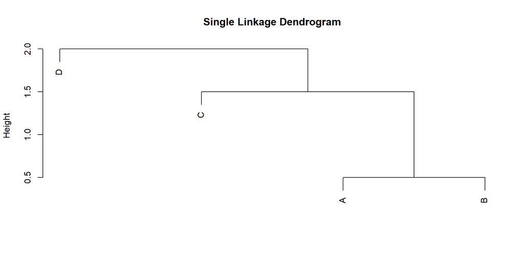

```r
# Data
points <- c(A=1, B=1.5, C=3, D=5)
hc <- hclust(dist(points), method="single")
plot(hc, main="Single Linkage Dendrogram", xlab="", sub="")
```

## Single Linkage - Step by Step

- Step 0: Calculate distance matrix for all pairs

```r
# Data with values as names
data <- c(1.0, 1.5, 3.0, 5.0)
names(data) <- c("1.0", "1.5", "3.0", "5.0")

#distance matrix
dist_matrix <- dist(data)
dist_matrix
```

```
    1.0 1.5 3.0
1.5 0.5
3.0 2.0 1.5
5.0 4.0 3.5 2.0
```

### 1st Merge

- Merge the two closest pair: {1.0} and {1.5} to obtain a new cluster {1.0, 1.5}. The height is 0.5.
- Update Distance matrix:
  - D({1.0,1.5}, {3.0}) = min(2.0,1.5) = 1.5
  - D({1.0,1.5}, {5.0}) = min(4.0,3.5) = 3.5
  - D({3.0}, {5.0}) = 2.0

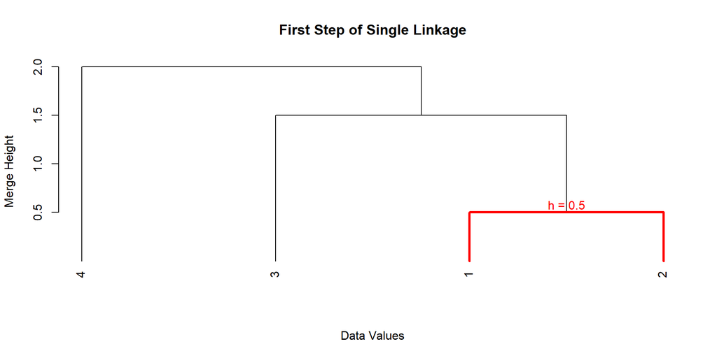

```r
# Data
data <- matrix(c(1.0, 1.5, 3.0, 5.0), ncol = 1)

# Hierarchical clustering
hc <- hclust(dist(data), method = "single")

# Plot dendrogram
plot(hc,
     main = "First Step of Single Linkage",
     xlab = "Data Values",
     ylab = "Merge Height",
     sub = "",
     hang = -1,
     ylim = c(0, 1))

# Find plotting positions of points 1.0 and 1.5
leaf_order <- hc$order

x1 <- which(leaf_order == 1)
x2 <- which(leaf_order == 2)

h <- hc$height[1]

# Highlight first merge only
segments(x1, 0, x1, h, col = "red", lwd = 3)
segments(x2, 0, x2, h, col = "red", lwd = 3)
segments(min(x1, x2), h,
         max(x1, x2), h,
         col = "red", lwd = 3)

# Label merge height
text(mean(c(x1, x2)),
     h + 0.08,
     labels = paste0("h = ", h),
     col = "red")
```

### 2nd Merge

- Merge the two closest pair: {1.0, 1.5} and {3.0} to obtain a new cluster {1.0, 1.5, 3.0}. The height is 1.5.
- Update Distance matrix:
  - D({1.0,1.5,3.0}, {5.0}) = min(4.0,3.5,2.0) = 2.0

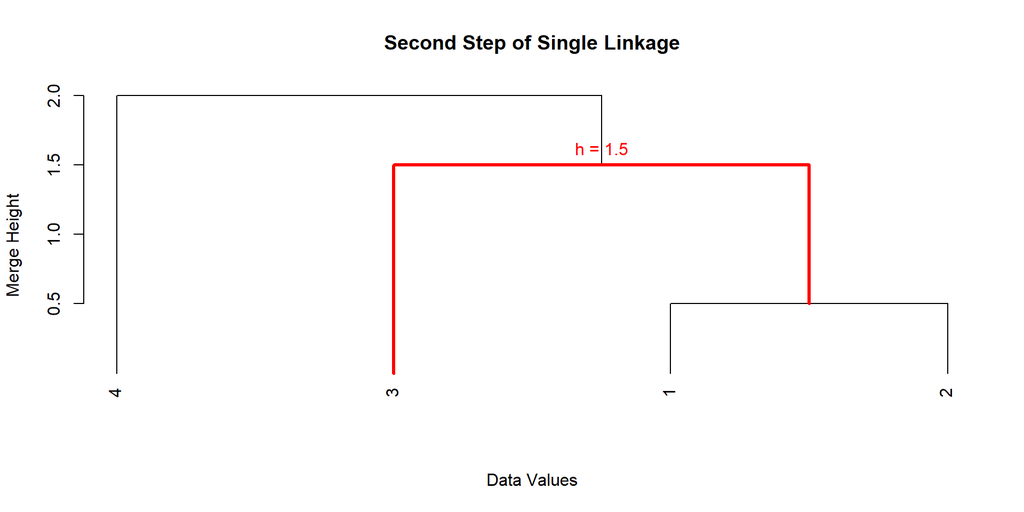

```r
# Data
data <- matrix(c(1.0, 1.5, 3.0, 5.0), ncol = 1)

# Hierarchical clustering
hc <- hclust(dist(data), method = "single")

# Plot dendrogram
plot(hc,
     main = "Second Step of Single Linkage",
     xlab = "Data Values",
     ylab = "Merge Height",
     sub = "",
     hang = -1,
     ylim = c(0, 2.5))

# Leaf order in the plotted dendrogram
leaf_order <- hc$order

# x-positions of original observations
x1 <- which(leaf_order == 1)
x2 <- which(leaf_order == 2)
x3 <- which(leaf_order == 3)

# Heights
h1 <- hc$height[1]   # first merge
h2 <- hc$height[2]   # second merge

# Midpoint of cluster {1,2}
x12 <- mean(c(x1, x2))

####################################
# Highlight second merge in red
####################################

# Existing cluster {1,2} up to second merge
segments(x12, h1,
         x12, h2,
         col = "red", lwd = 3)

# Point 3 up to second merge
segments(x3, 0,
         x3, h2,
         col = "red", lwd = 3)

# Horizontal merge line
segments(min(x12, x3), h2,
         max(x12, x3), h2,
         col = "red", lwd = 3)

# Label merge height
text(mean(c(x12, x3)),
     h2 + 0.12,
     labels = paste0("h = ", h2),
     col = "red")
```

### Final Merge

- Merge the two closest pair: {1.0, 1.5, 3.0} and {5.0} to obtain a new cluster {1.0, 1.5, 3.0, 5.0}. The height is 2.0.

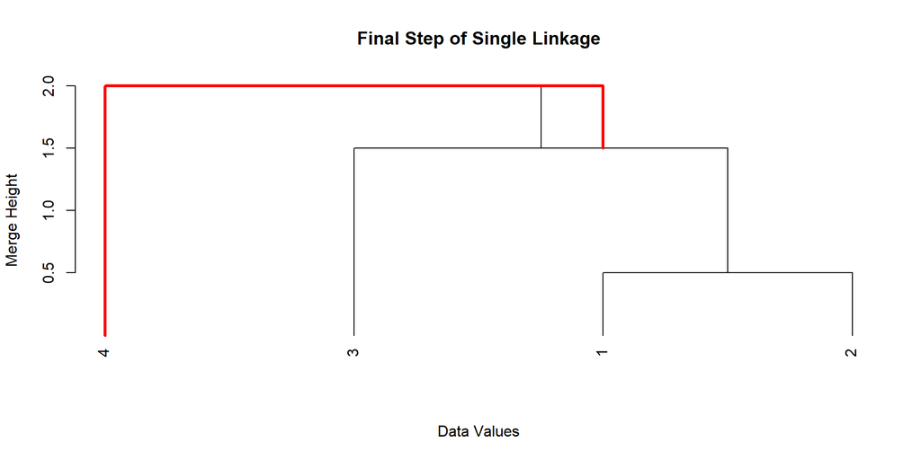

```r
# Data
data <- matrix(c(1.0, 1.5, 3.0, 5.0), ncol = 1)

# Hierarchical clustering
hc <- hclust(dist(data), method = "single")

# Plot dendrogram
plot(hc,
     main = "Final Step of Single Linkage",
     xlab = "Data Values",
     ylab = "Merge Height",
     sub = "",
     hang = -1,
     ylim = c(0, 4))

# Leaf order in plotted dendrogram
leaf_order <- hc$order

# x-positions of original observations
x1 <- which(leaf_order == 1)
x2 <- which(leaf_order == 2)
x3 <- which(leaf_order == 3)
x4 <- which(leaf_order == 4)

# Heights
h1 <- hc$height[1]
h2 <- hc$height[2]
h3 <- hc$height[3]

# Midpoint of cluster {1,2}
x12 <- mean(c(x1, x2))

# Midpoint of cluster {1,2,3}
x123 <- mean(c(x1, x2, x3))

####################################
# Highlight final merge in red
####################################

# Existing cluster {1,2,3} up to final merge
segments(x123, h2,
         x123, h3,
         col = "red", lwd = 3)

# Point 4 up to final merge
segments(x4, 0,
         x4, h3,
         col = "red", lwd = 3)

# Horizontal merge line
segments(min(x123, x4), h3,
         max(x123, x4), h3,
         col = "red", lwd = 3)

# Label final merge height
text(mean(c(x123, x4)),
     h3 + 0.15,
     labels = paste0("h = ", h3),
     col = "red")
```

## Step by Step using Single Linkage

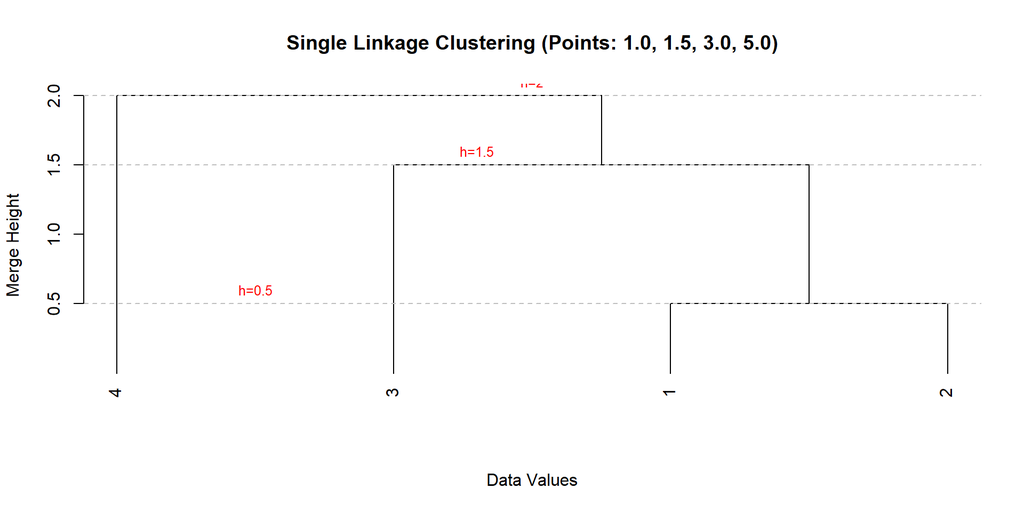

```r
# Compute clustering
hc <- hclust(dist(data), method = "single")

# Enhanced dendrogram plot
plot(hc,
     main = "Single Linkage Clustering (Points: 1.0, 1.5, 3.0, 5.0)",
     xlab = "Data Values",
     ylab = "Merge Height",
     sub = "",
     hang = -1)  # Aligns all leaves at bottom

# Add merge height labels
text(x = c(1.5, 2.3, 2.5),
     y = hc$height + 0.1,
     labels = paste0("h=", hc$height),
     col = "red", cex = 0.8)

# Add horizontal lines at merge heights
abline(h = hc$height, lty = 2, col = "gray")
```

## Common Linkage Memthods

| Method | Merge Rule | Height Meaning | Time Complexity |
| --- | --- | --- | --- |
| Single Linkage | Minimum distance between any two points | Minimum inter-cluster distance | O(n²) |
| Complete Linkage | Maximum distance between any two points | Maximum inter-cluster distance | O(n²) |
| Average Linkage | Mean distance between all point pairs | Average inter-cluster distance | O(n² log n) |
| Centroid Linkage | Distance between cluster centroids | Centroid separation (may invert) | O(n² log n) |

## Single Linkage (Minimum Distance)

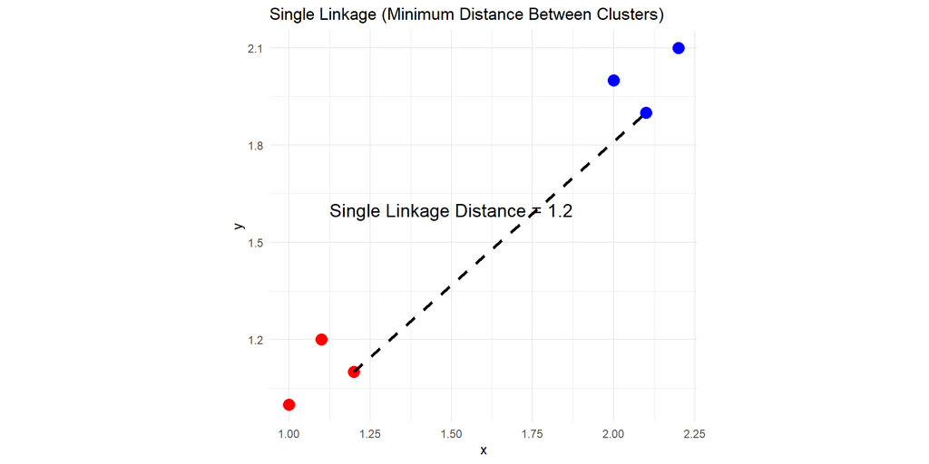

```r
# Create two simple clusters
set.seed(123)
cluster_A <- data.frame(x = c(1, 1.2, 1.1), y = c(1, 1.1, 1.2))
cluster_B <- data.frame(x = c(2, 2.2, 2.1), y = c(2, 2.1, 1.9))
dist_matrix <- as.matrix(dist(rbind(cluster_A, cluster_B)))[1:3, 4:6]

# Find the closest pair of points
distances <- as.matrix(dist(rbind(cluster_A, cluster_B)))[1:3, 4:6]
min_pair <- which(dist_matrix == min(dist_matrix), arr.ind = TRUE)
closest_A <- cluster_A[min_pair[1], ]
closest_B <- cluster_B[min_pair[2], ]

# Plot
ggplot() +
  geom_point(data = cluster_A, aes(x, y), color = "red", size = 4) +
  geom_point(data = cluster_B, aes(x, y), color = "blue", size = 4) +
  geom_segment(
    aes(x = closest_A$x, y = closest_A$y,
        xend = closest_B$x, yend = closest_B$y),
    color = "black", linetype = "dashed", linewidth = 1.2
  ) +
  geom_text(aes(x = 1.5, y = 1.6,
               label = paste("Single Linkage Distance =",
                            round(min(distances), 2))),
    size = 5
  ) +
  labs(title = "Single Linkage (Minimum Distance Between Clusters)") +
  theme_minimal() +
  coord_fixed()
```

## Complete Linkage (Maximum Distance)

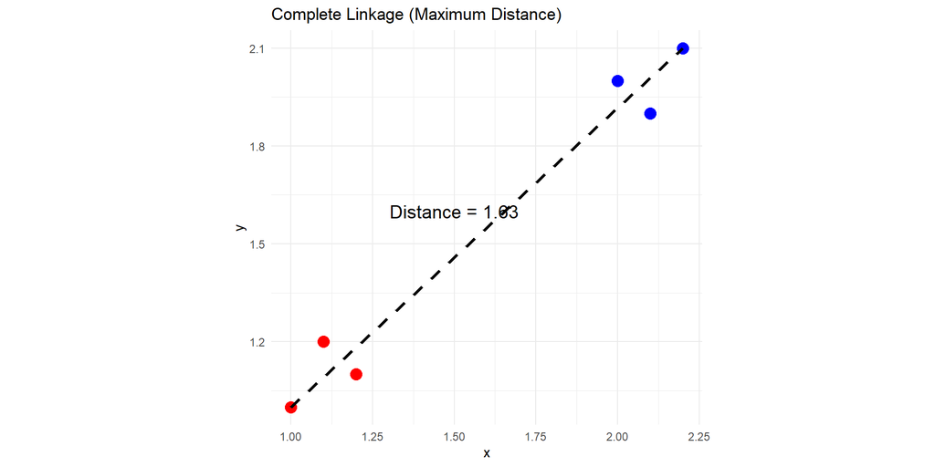

```r
# Find furthest pair
max_pair <- which(dist_matrix == max(dist_matrix), arr.ind = TRUE)
furthest_A <- cluster_A[max_pair[1], ]
furthest_B <- cluster_B[max_pair[2], ]

# Plot
ggplot() +
  geom_point(data = cluster_A, aes(x, y), color = "red", size = 4) +
  geom_point(data = cluster_B, aes(x, y), color = "blue", size = 4) +
  geom_segment(
    aes(x = furthest_A$x, y = furthest_A$y,
        xend = furthest_B$x, yend = furthest_B$y),
    color = "black", linetype = "dashed", linewidth = 1.2
  ) +
  geom_text(aes(x = 1.5, y = 1.6,
               label = paste("Distance =", round(max(dist_matrix), 2))),
    size = 5
  ) +
  labs(title = "Complete Linkage (Maximum Distance)") +
  theme_minimal() +
  coord_fixed()
```

## Average Linkage (Mean Distance)

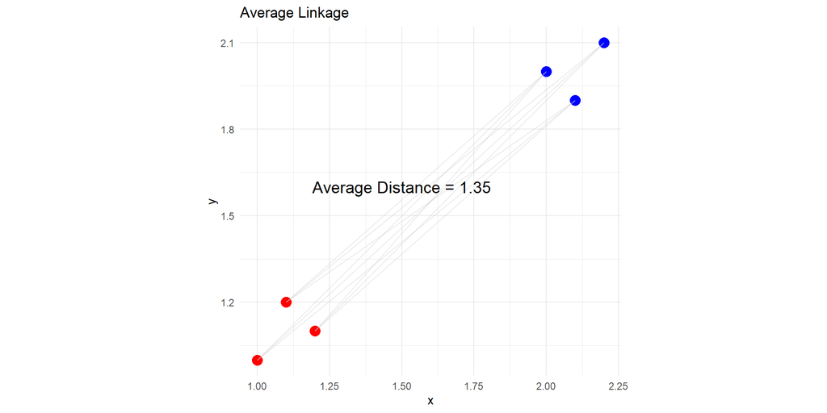

```r
# Calculate average distance
avg_distance <- mean(dist_matrix)

# Plot (showing all connections)
ggplot() +
  geom_point(data = cluster_A, aes(x, y), color = "red", size = 4) +
  geom_point(data = cluster_B, aes(x, y), color = "blue", size = 4) +
  # Draw all pairwise connections
  geom_segment(
    data = expand.grid(1:3, 1:3),
    aes(x = cluster_A$x[Var1], y = cluster_A$y[Var1],
        xend = cluster_B$x[Var2], yend = cluster_B$y[Var2]),
    color = "gray", alpha = 0.3
  ) +
  geom_text(aes(x = 1.5, y = 1.6,
               label = paste("Average Distance =", round(avg_distance, 2))),
    size = 5
  ) +
  labs(title = "Average Linkage") +
  theme_minimal() +
  coord_fixed()
```

## Centroid Linkage (Centroid Distance)

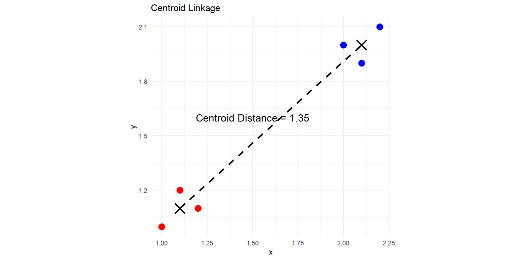

```r
# Calculate centroids
centroid_A <- c(mean(cluster_A$x), mean(cluster_A$y))
centroid_B <- c(mean(cluster_B$x), mean(cluster_B$y))
centroid_dist <- sqrt(sum((centroid_A - centroid_B)^2))

# Plot
ggplot() +
  geom_point(data = cluster_A, aes(x, y), color = "red", size = 4) +
  geom_point(data = cluster_B, aes(x, y), color = "blue", size = 4) +
  # Mark centroids
  geom_point(aes(x = centroid_A[1], y = centroid_A[2]),
             shape = 4, size = 5, stroke = 1.5) +
  geom_point(aes(x = centroid_B[1], y = centroid_B[2]),
             shape = 4, size = 5, stroke = 1.5) +
  # Draw centroid connection
  geom_segment(
    aes(x = centroid_A[1], y = centroid_A[2],
        xend = centroid_B[1], yend = centroid_B[2]),
    color = "black", linetype = "dashed", linewidth = 1.2
  ) +
  geom_text(aes(x = 1.5, y = 1.6,
               label = paste("Centroid Distance =", round(centroid_dist, 2))),
    size = 5
  ) +
  labs(title = "Centroid Linkage") +
  theme_minimal() +
  coord_fixed()
```

## Common Linkage Methods

```r
# Distance matrix
dist_matrix <- dist(c(1, 1.5, 3, 5))

# Set up plotting window
par(mfrow = c(2, 2))

# Function to plot dendrogram with title
plot_dendro <- function(hclust_method, title) {
  hc <- hclust(dist_matrix, method = hclust_method)
  plot(hc, main = title, xlab = "", sub = "",
       hang = -1, cex = 0.8)
  axis(2, at = seq(0, 5, by = 1), las = 1)  # Add y-axis labels
}

# Plot all methods
plot_dendro("single", "Single Linkage (MIN)")
plot_dendro("complete", "Complete Linkage (MAX)")
plot_dendro("average", "Average Linkage (UPGMA)")
plot_dendro("centroid", "Centroid Linkage (UPGMC)")
```

```r
# Reset plotting window
par(mfrow = c(1, 1))
```

[figure not shown]

# What to Cluster?

## Cluster Features or Subjects

- Cluster analysis can be used to group features or subjects.
- For example, in a dataset with hundreds of genes, we can cluster the features to find groups of similar genes or similar subjects.
- One can also simultaneously cluster both features and subjects.
- In R, this dual clustering can be done using the `heatmap` function, which uses hierarchical clustering to cluster both rows and columns of a matrix.

## Cluster Features or Subjects

```r
heatmap(as.matrix(iris[,-5]))
```

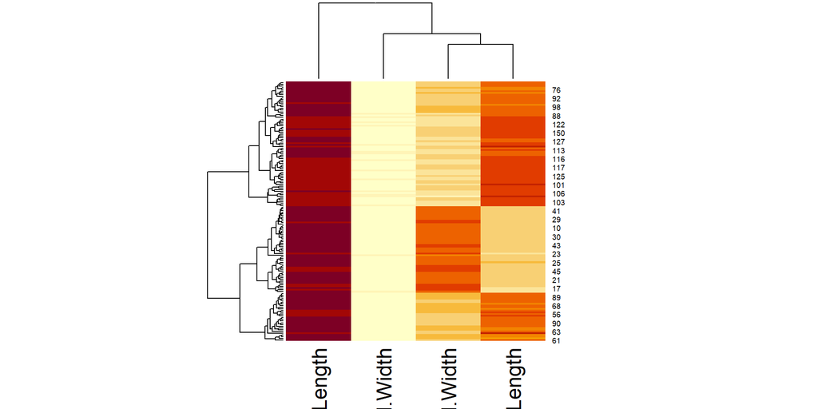

- More elegant heatmaps: pheatmap::pheatmap()

# K-means Clustering

## Introduction

- The idea goes back to Hugo Steinhaus (1956); the name was first used by James MacQueen (1967)
- K-means is a model-free clustering method
- Is is a type of nonhierarchical clustering
- Assign each observation to the cluster with the nearest centroid
- “Nearest” is usually defined on Euclidean distance
- The goal is to minimize within-cluster variances
- We need to decide whether or not to standardize observations
- There are variations such as more robust versions (k-medians, k-medoids) and model-based (Gaussian mixture)

## K-Means vs K-Nearest-Neighbors (KNN)

- Both are non-parametric
- K-means: unsupervised
- KNN: supervised
- K:
  - the number of neighbors in KNN
  - the number of clusters in K-Means

## How Does K-means Work

- We assume the number of classes, denoted by $K$, is known
- Let $\mathbf X_1, \cdots, \mathbf X_n$ denote $n$ observations in $\mathbb R^p$.
- Let $C_1, \cdots, C_K$ be the indices of membership
- Want to find $(C_1, \cdots, C_K)$ to minimize the objective function

$$\underset{C_1, \cdots, C_K}{min} \{
\sum_{k=1}^K \frac{1}{|C_K|}\sum_{i,i'} D^2(\mathbf X_i, \mathbf X_i')
\}$$

## How Does K-means Work

- The objective function is equivalent to
  $$\underset{C_1, \cdots, C_K}{min} \{
  \sum_{i=1}^n D^2(\mathbf X_i, \bar {\mathbf X}_{C_i})
  \}$$
  where $\bar {\mathbf X}_{C_i}$ is the centriod of cluster $C_i$.
- One widely used choice of $D$ is the Euclidean distance, i.e.,
  $$D^2(x,y)=||x-y||^2=(x-y)^T (x-y)$$

## K-Means: Algorithm

- Step 0: standardize data if appropriate
- Step 1: Partition the observations into K initial clusters. Alternatively, we can initialize K centroids
- Step 2: Assign each observation to its nearest cluster.
- Step 3: recalculate the centroids.
- Step 4: repeat 2-3 until no more changes in assignments

# K-Means Example: Cluster Iris Data using Petal Length and Petal Width

## Initialize clusters

- Two features: petal length and petal width

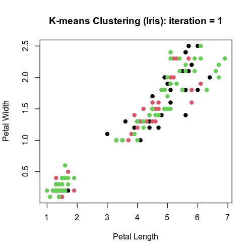

```r
library(magick)

##################################
## Define Squared Euclidean Distance
distxy <- function(x, y) {
  sum((x - y)^2)
}

mydata <- iris[, 3:4]

n <- nrow(mydata)
K <- 3

distance <- matrix(0, n, K)

## initialize
set.seed(1)

cluster01 <- rmultinom(n, size = 1,
                       prob = c(0.3, 0.3, 0.4))

cluster01.new <- rmultinom(n, size = 1,
                           prob = c(0.3, 0.3, 0.4))

cluster123 <- apply(cluster01.new, 2, which.max)

## store frames
frames <- list()

i <- 0

#while(sum(cluster01 != cluster01.new) ) {
while(i<4) {

  i <- i + 1

  ## open in-memory graphics device
  img <- image_graph(width = 500, height = 500, res = 96)

  plot(mydata[,1], mydata[,2],
       type = "n",
       xlab = "Petal Length",
       ylab = "Petal Width",
       main = paste("K-means Clustering (Iris): iteration =", i))

  for(k in 1:K) {
    points(mydata[cluster123 == k, 1],
           mydata[cluster123 == k, 2],
           col = k,
           pch = 19)
  }

  ## close device and capture image
  dev.off()

  ## save frame in memory
  frames[[i]] <- img

  ##################################
  ## K-means update

  centroids <- as.matrix(cluster01.new) %*%
    as.matrix(mydata) / rowSums(cluster01.new)

  ## avoid label switching
  centroids <- centroids[order(centroids[,1]), ]

  cluster01 <- cluster01.new

  for(k in 1:K) {
    distance[,k] <- apply(mydata, 1,
                          distxy,
                          centroids[k, ])
  }

  cluster123 <- apply(distance, 1, which.min)

  ## convert assignment to dummy variables
  cluster01.new <- matrix(0, K, n)

  for(k in 1:K) {
    cluster01.new[k, cluster123 == k] <- 1
  }

#  print(i)
#  print(table(cluster123))
}

##################################
## Create animation directly

img_joined <- image_join(frames)

img_animated <- image_animate(img_joined,
                              fps = 1)

## display
img_animated
```

## Initialize Centroids

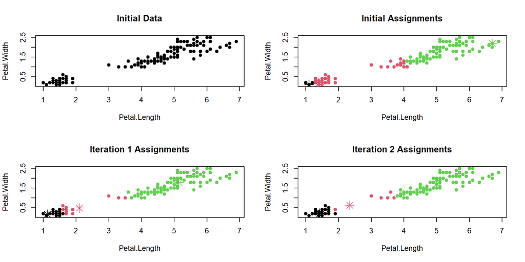

```r
#function to assign clusters for given centroids
assign_clusters <- function(data, centroids) {
  distances <- as.matrix(dist(rbind(as.matrix(data), centroids)))
  cluster_assignments <- apply(distances[1:nrow(data), (nrow(data) + 1):(nrow(data) + k)], 1, which.min)
  return(cluster_assignments)
}

#function to calculate centroids for given cluster assignments
calculate_centroids <- function(data, clusters, k) {
  centroids <- matrix(NA, nrow = k, ncol = ncol(data))
  for (i in 1:k) {
    centroids[i, ] <- colMeans(data[clusters == i, ])
  }
  return(centroids)
}

# Load the iris dataset
data(iris)
# Set the number of clusters
k <- 3
# we will perform the first three iteractions of k-means
set.seed(123) # Set seed for reproducibility
par(mfrow = c(2, 2))
#plot data
plot(iris[, 3:4], col = "black", pch = 19, main = "Initial Data")


# step by step
#Iteration 0:
# Step a: Randomly select initial centroids
centroids <- iris[sample(1:nrow(iris), k), 3:4]
# Step b: Assign each observation to the nearest centroid
clusters <- assign_clusters(iris[, 3:4], centroids)
#initial assignments
plot(iris[, 3:4], col = clusters, pch = 19, main = "Initial Assignments")
points(centroids, col = 1:k, pch = 8, cex = 2)


# Iteration 1:
# Step a: Assign clusters based on initial centroids
centroids <- calculate_centroids(iris[, 3:4], clusters, k)
# Step b: Calculate centroids
clusters <- assign_clusters(iris[, 3:4], centroids)
plot(iris[, 3:4], col = clusters, pch = 19, main = "Iteration 1 Assignments")
points(centroids, col = 1:k, pch = 8, cex = 2)


# Iteration 2
# Step a: calculate centroids
centroids <- calculate_centroids(iris[, 3:4], clusters, k)
# Step b: Assign clusters based on new centroids
clusters <- assign_clusters(iris[, 3:4], centroids)
plot(iris[, 3:4], col = clusters, pch = 19, main = "Iteration 2 Assignments")
points(centroids, col = 1:k, pch = 8, cex = 2)
```

## Remarks

- The algorithm is guaranteed to decrease the objective function
- It might converge to local minimum
- Use different and random initial values

## Different Initial Values

- Different initial values can lead to different clustering results.

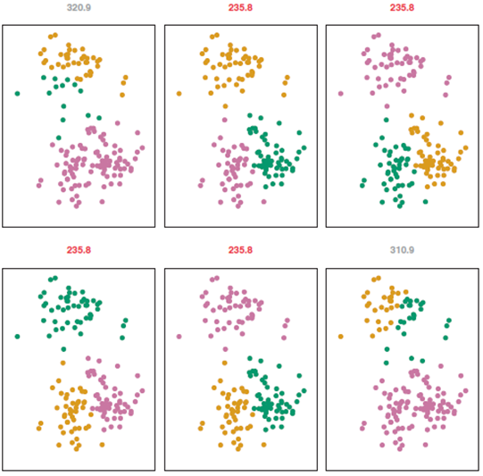

```r
knitr::include_graphics("img/Iris_kmeans_InitialValues.png")
```

## Different Initial Values

- The ‘kmeans’ function in R allows multiple sets of initial values and selects the solution with the smallest within-cluster sum of squares.
- This can be specified using the ‘nstart’ argument.
- Since the K-means algorithm may converge to a local minimum, using multiple random initializations often leads to a better clustering solution.
- The default setting is nstart = 1, meaning that only one random initialization is used.

```r
kmeans(data.frame(iris[,-5]),centers=3, nstart=5)
```

```
K-means clustering with 3 clusters of sizes 62, 50, 38

Cluster means:
  Sepal.Length Sepal.Width Petal.Length Petal.Width
1     5.901613    2.748387     4.393548    1.433871
2     5.006000    3.428000     1.462000    0.246000
3     6.850000    3.073684     5.742105    2.071053

Clustering vector:
  [1] 2 2 2 2 2 2 2 2 2 2 2 2 2 2 2 2 2 2 2 2 2 2 2 2 2 2 2 2 2 2 2 2 2 2 2 2 2
 [38] 2 2 2 2 2 2 2 2 2 2 2 2 2 1 1 3 1 1 1 1 1 1 1 1 1 1 1 1 1 1 1 1 1 1 1 1 1
 [75] 1 1 1 3 1 1 1 1 1 1 1 1 1 1 1 1 1 1 1 1 1 1 1 1 1 1 3 1 3 3 3 3 1 3 3 3 3
[112] 3 3 1 1 3 3 3 3 1 3 1 3 1 3 3 1 1 3 3 3 3 3 1 3 3 3 3 1 3 3 3 1 3 3 3 1 3
[149] 3 1

Within cluster sum of squares by cluster:
[1] 39.82097 15.15100 23.87947
 (between_SS / total_SS =  88.4 %)

Available components:

[1] "cluster"      "centers"      "totss"        "withinss"     "tot.withinss"
[6] "betweenss"    "size"         "iter"         "ifault"
```

# Rand Index

## Rand Index

- **Definition**:  
  A metric (0 ≤ RI ≤ 1) measuring similarity between two clusterings by counting pairwise agreements:
- **Agreement**:
  - Same cluster in both results *or*
  - Different clusters in both results
- **Disagreement**: Points grouped differently.
- **Interpretation**:
  - 1: Perfect match
  - 0: No agreement

## Rand Index

**Formula**:
$$\text{Rand Index} = \frac{a + b}{a + b + c + d}$$

| Symbol | Meaning |
| --- | --- |
| $a$ | Pairs in same cluster in both |
| $b$ | Pairs in different clusters both |
| $c$ | Same in 1st, different in 2nd |
| $d$ | Different in 1st, same in 2nd |

## Rand Index Example

```r
library(cluster)
set.seed(123)
# K-means clustering
kmeans_clusters <- kmeans(iris[, 1:4], centers = 3)$cluster
# Hierarchical clustering
hclust_clusters <- cutree(hclust(dist(iris[, 1:4])), k = 3)

# Calculate Rand Index
rand_index <- function(cluster1, cluster2) {
  # Create contingency table
  tab <- table(cluster1, cluster2)

  # Calculate combinations
  n <- sum(tab)
  a <- sum(choose(tab, 2))  # Pairs in same cluster in both
  b <- sum(choose(rowSums(tab), 2)) - a  # Pairs in same cluster only in cluster1
  c <- sum(choose(colSums(tab), 2)) - a  # Pairs in same cluster only in cluster2
  d <- choose(n, 2) - a - b - c          # Pairs in different clusters in both

  # Rand Index formula
  (a + d) / (a + b + c + d)
}

# Usage
ri <- rand_index(kmeans_clusters, hclust_clusters)
print(paste("Manual Rand Index:", round(ri, 3)))
```

```
[1] "Manual Rand Index: 0.799"
```

# Further Topics

## Further Topics: Number of Clusters

- Elbow method
- Silhouette method
- Gap statistic
- CH index
- Dunn index
- Model-based clustering